# R Notebook

# Final Report

In this project I aim to predict house prices based on data about the houses themselves. The following is a summary of the process of preparing the data, creation of additional features, and building the final model to make the predictions. In the end, this model is then used to make predictions on a blind test set with unknown observed values.

Several different libraries were used, and I made many utility functions for preprocessing the data, creating additional features, performing feature selection, and tuning the final model. Before each of the modeling steps I run the following script to load all of those libraries and utility functions.

```r
setwd("..")
```

```
The working directory was changed to C:/Users/Dan/Documents/MBD/Term3/Advanced R/individual_assignment inside a notebook chunk. The working directory will be reset when the chunk is finished running. Use the knitr root.dir option in the setup chunk to change the working directory for notebook chunks…
```

```r
source("./scripts/load_dependencies.R")
```

### The Data

```r
setwd("..")
```

```
The working directory was changed to C:/Users/Dan/Documents/MBD/Term3/Advanced R/individual_assignment inside a notebook chunk. The working directory will be reset when the chunk is finished running. Use the knitr root.dir option in the setup chunk to change the working directory for notebook chunks…
```

```r
hp_train <- fread("./data/house_price_train.csv")
```

The following graph shows the distribution of these features. For more graphs, see “scripts/EDA.R”

```r
summary(hp_train)
```

```
       id                 date               price            bedrooms        bathrooms
 Min.   :   1000102   Length:17277       Min.   :  78000   Min.   : 1.000   Min.   :0.500
 1st Qu.:2113701080   Class :character   1st Qu.: 320000   1st Qu.: 3.000   1st Qu.:1.750
 Median :3902100205   Mode  :character   Median : 450000   Median : 3.000   Median :2.250
 Mean   :4566440237                      Mean   : 539865   Mean   : 3.369   Mean   :2.114
 3rd Qu.:7302900090                      3rd Qu.: 645500   3rd Qu.: 4.000   3rd Qu.:2.500
 Max.   :9900000190                      Max.   :7700000   Max.   :33.000   Max.   :8.000
  sqft_living       sqft_lot           floors        waterfront            view          condition
 Min.   :  370   Min.   :    520   Min.   :1.000   Min.   :0.000000   Min.   :0.0000   Min.   :1.000
 1st Qu.: 1430   1st Qu.:   5050   1st Qu.:1.000   1st Qu.:0.000000   1st Qu.:0.0000   1st Qu.:3.000
 Median : 1910   Median :   7620   Median :1.500   Median :0.000000   Median :0.0000   Median :3.000
 Mean   : 2080   Mean   :  15186   Mean   :1.493   Mean   :0.007467   Mean   :0.2335   Mean   :3.413
 3rd Qu.: 2550   3rd Qu.:  10695   3rd Qu.:2.000   3rd Qu.:0.000000   3rd Qu.:0.0000   3rd Qu.:4.000
 Max.   :13540   Max.   :1164794   Max.   :3.500   Max.   :1.000000   Max.   :4.0000   Max.   :5.000
     grade         sqft_above   sqft_basement       yr_built     yr_renovated        zipcode
 Min.   : 3.00   Min.   : 370   Min.   :   0.0   Min.   :1900   Min.   :   0.00   Min.   :98001
 1st Qu.: 7.00   1st Qu.:1190   1st Qu.:   0.0   1st Qu.:1951   1st Qu.:   0.00   1st Qu.:98033
 Median : 7.00   Median :1564   Median :   0.0   Median :1975   Median :   0.00   Median :98065
 Mean   : 7.66   Mean   :1791   Mean   : 289.4   Mean   :1971   Mean   :  85.35   Mean   :98078
 3rd Qu.: 8.00   3rd Qu.:2210   3rd Qu.: 556.0   3rd Qu.:1997   3rd Qu.:   0.00   3rd Qu.:98117
 Max.   :13.00   Max.   :9410   Max.   :4820.0   Max.   :2015   Max.   :2015.00   Max.   :98199
      lat             long        sqft_living15    sqft_lot15
 Min.   :47.16   Min.   :-122.5   Min.   : 460   Min.   :   659
 1st Qu.:47.47   1st Qu.:-122.3   1st Qu.:1490   1st Qu.:  5100
 Median :47.57   Median :-122.2   Median :1840   Median :  7639
 Mean   :47.56   Mean   :-122.2   Mean   :1986   Mean   : 12826
 3rd Qu.:47.68   3rd Qu.:-122.1   3rd Qu.:2360   3rd Qu.: 10080
 Max.   :47.78   Max.   :-121.3   Max.   :6210   Max.   :871200
```

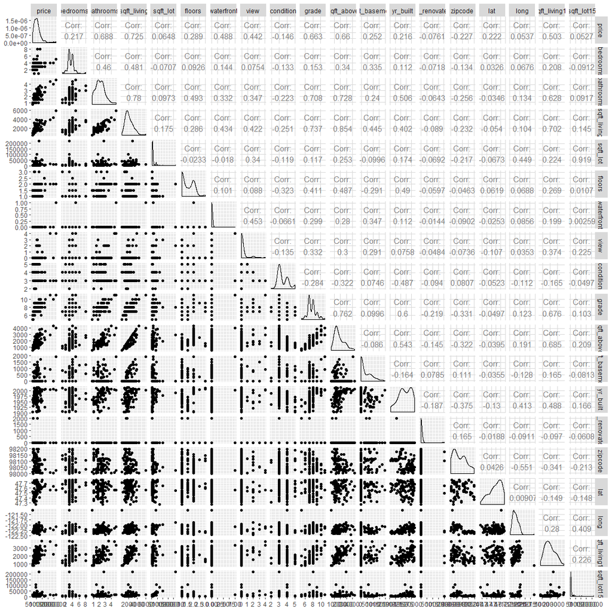

```r
# Just to speed things up - should  still give a good idea of the distribution
ggpairs(hp_train[sample(nrow(hp_train), 100), 3:ncol(hp_train)], progress=FALSE)
```

### Preprocessing

We want to convert the date into individual features to split it from a very large factor variable into numeric features.

Additionally, the ID will not help us in making predictions so we will drop it.

The code for these preprocessing steps can be found in “scripts/preprocessing.R”

```r
pp <- c(create_date_features, rm_zip, rm_id)
for (p_step in pp) {
  hp_train <- p_step(hp_train)
}
summary(hp_train)
```

```
     price            bedrooms        bathrooms      sqft_living       sqft_lot           floors
 Min.   :  78000   Min.   : 1.000   Min.   :0.500   Min.   :  370   Min.   :    520   Min.   :1.000
 1st Qu.: 320000   1st Qu.: 3.000   1st Qu.:1.750   1st Qu.: 1430   1st Qu.:   5050   1st Qu.:1.000
 Median : 450000   Median : 3.000   Median :2.250   Median : 1910   Median :   7620   Median :1.500
 Mean   : 539865   Mean   : 3.369   Mean   :2.114   Mean   : 2080   Mean   :  15186   Mean   :1.493
 3rd Qu.: 645500   3rd Qu.: 4.000   3rd Qu.:2.500   3rd Qu.: 2550   3rd Qu.:  10695   3rd Qu.:2.000
 Max.   :7700000   Max.   :33.000   Max.   :8.000   Max.   :13540   Max.   :1164794   Max.   :3.500
   waterfront            view          condition         grade         sqft_above   sqft_basement
 Min.   :0.000000   Min.   :0.0000   Min.   :1.000   Min.   : 3.00   Min.   : 370   Min.   :   0.0
 1st Qu.:0.000000   1st Qu.:0.0000   1st Qu.:3.000   1st Qu.: 7.00   1st Qu.:1190   1st Qu.:   0.0
 Median :0.000000   Median :0.0000   Median :3.000   Median : 7.00   Median :1564   Median :   0.0
 Mean   :0.007467   Mean   :0.2335   Mean   :3.413   Mean   : 7.66   Mean   :1791   Mean   : 289.4
 3rd Qu.:0.000000   3rd Qu.:0.0000   3rd Qu.:4.000   3rd Qu.: 8.00   3rd Qu.:2210   3rd Qu.: 556.0
 Max.   :1.000000   Max.   :4.0000   Max.   :5.000   Max.   :13.00   Max.   :9410   Max.   :4820.0
    yr_built     yr_renovated          lat             long        sqft_living15    sqft_lot15
 Min.   :1900   Min.   :   0.00   Min.   :47.16   Min.   :-122.5   Min.   : 460   Min.   :   659
 1st Qu.:1951   1st Qu.:   0.00   1st Qu.:47.47   1st Qu.:-122.3   1st Qu.:1490   1st Qu.:  5100
 Median :1975   Median :   0.00   Median :47.57   Median :-122.2   Median :1840   Median :  7639
 Mean   :1971   Mean   :  85.35   Mean   :47.56   Mean   :-122.2   Mean   :1986   Mean   : 12826
 3rd Qu.:1997   3rd Qu.:   0.00   3rd Qu.:47.68   3rd Qu.:-122.1   3rd Qu.:2360   3rd Qu.: 10080
 Max.   :2015   Max.   :2015.00   Max.   :47.78   Max.   :-121.3   Max.   :6210   Max.   :871200
      day             month            year
 Min.   : 1.000   Min.   : 1.00   Min.   :2014
 1st Qu.: 4.000   1st Qu.: 8.00   1st Qu.:2014
 Median : 6.000   Median :16.00   Median :2014
 Mean   : 6.567   Mean   :15.69   Mean   :2014
 3rd Qu.: 9.000   3rd Qu.:23.00   3rd Qu.:2015
 Max.   :12.000   Max.   :31.00   Max.   :2015
```

### Feature Creation

The next thing I wanted to do was create some additional features based on what I had. The features I created are as follows:

yrs_since_renovated: Many of the homes have been renovated since they were originally built. This feature supposes that the amount of time since the last time the house was renovated has an impact on the price. It is the number of years between the renovation and sale of the home. If the house was never renovated, then it is the number of years since the house was built.

sum_grades: Several of the features are ranked categorical variables that I treat as numeric. These are view, grade, and condition. This feature combines these by adding them together.

bed_bath_ratio: This feature is the ratio of bedrooms to bathrooms. It is assumed that the number of bedrooms corresponds roughly with the number of inhabitants, so a high ratio would be a bad thing and therefore have a negative impact on the price (at least, this is the supposition).

size_yard: Since available information includes both the square footage of the living space and the square footage of the lot that the house stands on, we can estimate the amount of property that is not occupied by the house, or a yard. Presumably this is a good thing and would have a positive impact on the price of the house.

cluster_loc: To explicitly group houses based on location, the DBSCAN clustering algorithm was used on latitude and longitude to make clusters of the houses based on their location.

The code for feature creation can be found in “scripts/feature_creation.R”

```r
original_features <- names(hp_train)
fc <- c(yrs_since_renovated, sum_grades, bed_bath_ratio, size_yard, cluster_loc)
for (create_step in fc) {
  hp_train <- create_step(hp_train)
}
hp_train[,setdiff(names(hp_train), original_features)]
```

```
[1] "yrs_since_renovated" "grade_sums"          "bed_bath_ratio"      "yard"
[5] "loc_cluster"
```

### Feature Selection

Since many of the features may not have a big impact on the final result of the model, we want to remove some to find the ideal number of features for the best result. To do this Recursive Feature Elimination was used, performing 3-fold cross validation to see which combination of features has the best result. All columns were tried, and the decreasing by 10% of the columns down to 70% of the original features.

To save time on execution, here we will simply read the final model built and print the feature names.

The code for the RFE used can be found in “scrips/feature_selection.R”

```r
setwd("..")
```

```
The working directory was changed to C:/Users/Dan/Documents/MBD/Term3/Advanced R/individual_assignment inside a notebook chunk. The working directory will be reset when the chunk is finished running. Use the knitr root.dir option in the setup chunk to change the working directory for notebook chunks…
```

```r
final_model <- readRDS("./models/rf_model_gridsearch.rds")
final_model$coefnames
```

```
 [1] "lat"                 "long"                "sqft_living"         "grade_sums"
 [5] "sqft_living15"       "yr_built"            "grade"               "yrs_since_renovated"
 [9] "sqft_above"          "sqft_lot15"          "sqft_lot"            "yard"
[13] "waterfront"          "yr_renovated"        "bathrooms"           "condition"
[17] "floors"              "sqft_basement"       "view"                "bed_bath_ratio"
[21] "bedrooms"            "loc_cluster_1"       "loc_cluster_0"       "year"
```

### Modeling

Finally, models were built. The best result found was Random Forest, so this is the algorithm we will focus on here. To tune the random forest, a grid search was performed on the number of columns used for each tree (mtry) and the number of records required to make a split.

The results are as follows:

```r
final_model$results
```

|  | mtry | splitrule | min.node.size | RMSE | RSquared | MAE | MAPE | RMSESD | RSquaredSD | MAESD | MAPESD |
| --- | --- | --- | --- | --- | --- | --- | --- | --- | --- | --- | --- |
| 1 | 10 | variance | 2 | 131411.5 | 0.8739832 | 70889.35 | 0.1332169 | 6070.779 | 0.01350468 | 1522.283 | 0.002520854 |
| 2 | 10 | variance | 5 | 131755.1 | 0.8732598 | 71006.94 | 0.1334001 | 5611.120 | 0.01259588 | 1475.617 | 0.002536010 |
| 3 | 10 | variance | 10 | 132202.6 | 0.8726924 | 71433.53 | 0.1341418 | 5627.328 | 0.01265522 | 1429.738 | 0.002436705 |
| 4 | 15 | variance | 2 | 128664.8 | 0.8784819 | 69568.59 | 0.1307472 | 5786.865 | 0.01233467 | 1509.145 | 0.002502091 |
| 5 | 15 | variance | 5 | 129520.6 | 0.8767787 | 69825.68 | 0.1311235 | 5822.434 | 0.01240392 | 1449.480 | 0.002567502 |
| 6 | 15 | variance | 10 | 129740.6 | 0.8765093 | 69920.72 | 0.1313048 | 5405.599 | 0.01150854 | 1379.752 | 0.002519634 |
| 7 | 20 | variance | 2 | 128397.2 | 0.8785580 | 69150.83 | 0.1298388 | 5754.245 | 0.01205671 | 1524.958 | 0.002646874 |
| 8 | 20 | variance | 5 | 128304.8 | 0.8786720 | 69278.30 | 0.1300567 | 6399.184 | 0.01303313 | 1614.281 | 0.002628413 |
| 9 | 20 | variance | 10 | 129296.5 | 0.8770576 | 69530.32 | 0.1304137 | 6040.850 | 0.01273325 | 1576.028 | 0.002524591 |

The MAPE in cross validation tended to be around 13%. Since these models are essentially trained with only 2/3s of the data and use the last third for testing, the final score from the final model should be slightly better since it will be trained on the entire dataset.

|  | mtry | splitrule | min.node.size | RMSE | RSquared | MAE | MAPE | RMSESD | RSquaredSD | MAESD | MAPESD |
| --- | --- | --- | --- | --- | --- | --- | --- | --- | --- | --- | --- |
| 7 | 20 | variance | 2 | 128397.2 | 0.878558 | 69150.83 | 0.1298388 | 5754.245 | 0.01205671 | 1524.958 | 0.002646874 |

The code for the modeling steps can be found in “scripts/models.R”. This includes several models that proved to not work as well as the final model that was tuned. The code for the pipeline that applies the preprocessing, creation, and selection steps as well as the modeling can be found in “scripts/pipeline_casero.R”

### Making Predictions

Now that a final model has been tuned, the final step is to apply the model to the blind test set to make predicitons. These predictions are written to a file called “guesses.csv”

(Note: the following code is just a copy of “script/make_predictions.R”)

```r
setwd("..")
```

```
The working directory was changed to C:/Users/Dan/Documents/MBD/Term3/Advanced R/individual_assignment inside a notebook chunk. The working directory will be reset when the chunk is finished running. Use the knitr root.dir option in the setup chunk to change the working directory for notebook chunks…
```

```r
hp_test <- fread("./data/house_price_test.csv")
pp <- c(create_date_features, rm_zip, rm_id)
fc <- c(yrs_since_renovated, sum_grades, bed_bath_ratio, size_yard, cluster_loc)
make_predictions <- function(df, preprocessing, feature_creation, train_obj) {
  df <- data.table(df)

  for(f in c(preprocessing,feature_creation)) {
    df <- f(df)
  }

  print(names(df))

  df <- one_hot(df)[,train_obj$coefnames,with=F]

  return(predict(train_obj$finalModel, df))
}
preds <- make_predictions(hp_test, pp, fc, final_model)
```

```
 [1] "bedrooms"            "bathrooms"           "sqft_living"         "sqft_lot"
 [5] "floors"              "waterfront"          "view"                "condition"
 [9] "grade"               "sqft_above"          "sqft_basement"       "yr_built"
[13] "yr_renovated"        "lat"                 "long"                "sqft_living15"
[17] "sqft_lot15"          "day"                 "month"               "year"
[21] "yrs_since_renovated" "grade_sums"          "bed_bath_ratio"      "yard"
[25] "loc_cluster"
```

```r
guesses <- data.table(id=hp_test$id, pred=preds$predictions)
fwrite(guesses, "./data/guesses.csv")
```